# Famílias de Distribuições de Probabilidade

Delineamento e Estatística

Nicholas A. C. Marino

github.com/nacmarino/metodosR

## Distribuições de Probabilidade

- A distribuição de probabilidade de uma variável *X* descreve de que forma a probabilidade de obter um dado valor *x* está distribuída entre todas as possibilidades existentes em *X*.
- As distribuições de probabilidade são baseadas em diferentes tipos de famílias de distribuição de probabilidade:
  - Gaussiana (Normal);
  - Binomial;
  - Poisson;
  - Gamma;
  - Beta;
  - Binomial Negativa;
  - Uniforme;
  - …
- Cada família de distribuição de probabilidade possui características específicas que justificam e limitam o seu uso.

## Gerando números aleatórios de acordo com diferentes famílias de distribuição de probabilidade

- Você pode gerar número aleatórios a partir da maioria das famílias de distribuição de probabilidade utilizando a linguagem R;
- Toda função que gera número aleatórios na linguagem R é iniciada pela letra `r` (*random*):
  - `rnorm`: para variáveis aleatórias que seguem a distribuição **Gaussiana/Normal**;
  - `rbinom`: para variáveis aleatórias que seguem a distribuição **Binomial**;
  - `rpois`: para variáveis aleatórias que seguem a distribuição **Poisson**;
  - `rnbinom`: para variáveis aleatórias que seguem a distribuição **Binomial Negativa**;
  - `runif`: para variáveis aleatórias que seguem a distribuição **Uniforme**;
  - `rgamma()`: para variáveis aleatórias que seguem a distribuição **Gamma**;
  - …
- Um exemplo com a distribuição Normal:

```r
options(digits = 3)
set.seed(33)
rnorm(n = 100, mean = 10, sd = 1)
```

```
##   [1]  9.86  9.96 11.01  9.84  7.84 10.50  9.24 10.78 10.75  8.90 10.17
##  [12]  9.97 11.88 10.24 10.70  9.98  9.86 10.32 10.12  9.41  9.56 10.29
##  [23] 10.72 10.46 10.19 10.23 10.59 12.00  8.16  9.14 11.58 10.16  9.72
##  [34] 10.79  9.78 11.39  9.51 10.14 10.00  9.27  9.28  9.81 11.34 10.36
##  [45] 10.84 10.77 10.08  9.33 11.84  9.79  9.46  8.50 10.27 10.03  9.00
##  [56]  9.23  9.42  9.07  7.82  9.49 10.09 10.29 10.69  8.39 10.19 10.08
##  [67]  9.83  8.60  9.63 10.45 11.63 11.92  9.84  9.56 11.19 11.67 11.13
##  [78]  8.48 12.73 10.50  8.51 10.92  9.48 12.11  9.11  9.83 10.91  8.61
##  [89] 10.81  9.04  9.63 11.48  9.40  9.71  8.22 12.26  9.33 10.48  8.84
## [100]  9.62
```

- Podemos criar um histograma para visualizar a distribuição de probabilidade de obtermos cada um dos valores observados acima.

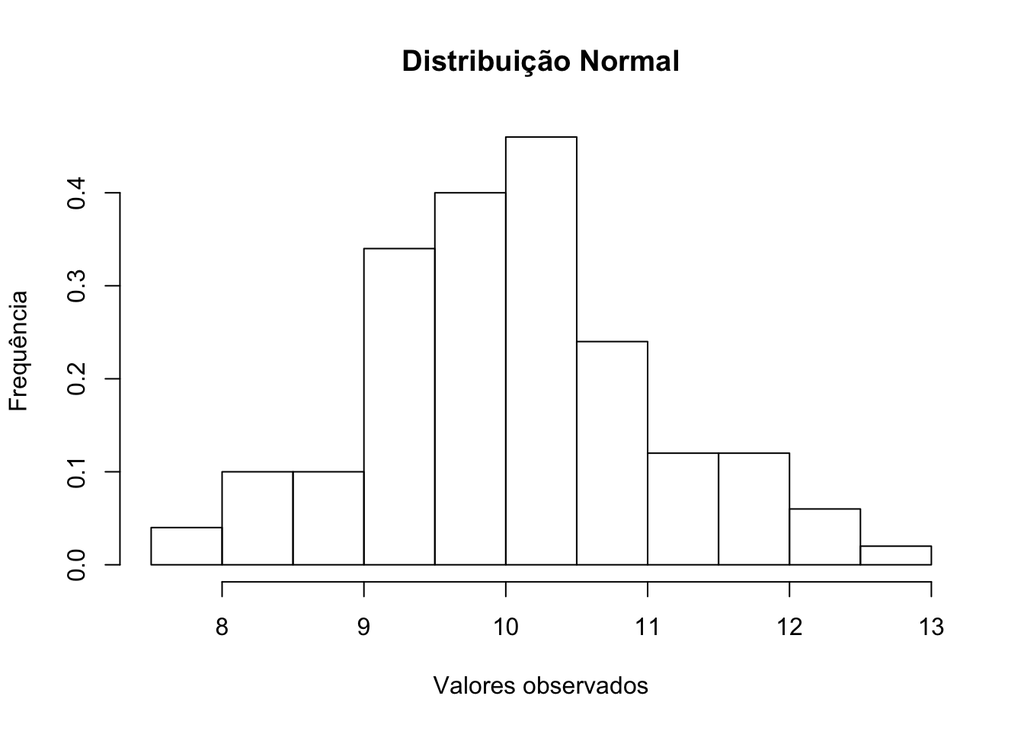

```r
set.seed(33)
hist(x = rnorm(n = 100, mean = 10, sd = 1), main = "Distribuição Normal", xlab = "Valores observados", ylab = "Frequência", freq = FALSE)
```

- O que acontece se modificarmos os valores fornecidos à função?

```r
library(manipulate)
set.seed(33)
manipulate(
  hist(x = rnorm(n = tamanho, mean = media, sd = desvio), main = "Distribuição Normal",
       xlab = "Valores observados", ylab = "Frequência", freq = FALSE),
           tamanho = slider(10, 1000, step = 50),
           media = slider(0, 100, step = 0.5),
           desvio = slider(1, 6, step = 0.5))
```

> A probabilidade de obtermos um valor *x* a partir de uma população *X* muda de acordo com o tamanho da amostra, o valor estimado da média e o erro associado à essa estimativa.
- O que acontece agora se tentarmos usar outra família de distribuição de probabilidade?

```r
rpois(n = 100, mean = 10, sd = 1)
```

- A distribuição de Poisson não é descrita por uma *média* e um *desvio padrão*, mas sim por um parâmetro chamado *lambda*, que representa tanto a sua média quanto o erro ao redor desta média. De forma similar, a distribuição binomial é descrita pelo número de tentativas (*n*) e a probabilidade de sucesso em cada uma delas (*p*), e assim sucessivamente para cada família distribuição de probabilidade.

```r
set.seed(33)
manipulate(
  hist(x = rpois(n = tamanho, lambda = estimativa), main = "Distribuição de Poisson",
       xlab = "Valores observados", ylab = "Frequência", freq = FALSE),
           tamanho = slider(10, 50, step = 5),
           estimativa = slider(1, 50, step = 1))
```

> Cada família de distribuição de probabilidade é descrita por um conjunto diferente de parâmetros, que também descrevem aspectos diferentes de cada uma destas distribuições.
- Algumas famílias de distribuição de probabilidade trabalham com valores **discretos** e outras com valores **contínuos**.

```r
set.seed(33)
rnorm(n = 100, mean = 10, sd = 1)
```

```
##   [1]  9.86  9.96 11.01  9.84  7.84 10.50  9.24 10.78 10.75  8.90 10.17
##  [12]  9.97 11.88 10.24 10.70  9.98  9.86 10.32 10.12  9.41  9.56 10.29
##  [23] 10.72 10.46 10.19 10.23 10.59 12.00  8.16  9.14 11.58 10.16  9.72
##  [34] 10.79  9.78 11.39  9.51 10.14 10.00  9.27  9.28  9.81 11.34 10.36
##  [45] 10.84 10.77 10.08  9.33 11.84  9.79  9.46  8.50 10.27 10.03  9.00
##  [56]  9.23  9.42  9.07  7.82  9.49 10.09 10.29 10.69  8.39 10.19 10.08
##  [67]  9.83  8.60  9.63 10.45 11.63 11.92  9.84  9.56 11.19 11.67 11.13
##  [78]  8.48 12.73 10.50  8.51 10.92  9.48 12.11  9.11  9.83 10.91  8.61
##  [89] 10.81  9.04  9.63 11.48  9.40  9.71  8.22 12.26  9.33 10.48  8.84
## [100]  9.62
```

```r
set.seed(33)
rpois(n = 100, lambda = 10)
```

```
##   [1]  9  9 13  9  3  7 12 12  6  4 15 10 12  9  9 11 10  8  8 10 12 11 10
##  [24] 10 11 16 14 15 14  9  8  9 14  5  7  9  5 12 12 10  7 12  5  7  6 10
##  [47]  6 17  6 12  4 13  8 14  8 10 12 13 13 10 14  7 13  5 11  8 14  8 10
##  [70] 10 11  7  5  8 16  9  4 10 10 11 13 13  8  7  5  5 10  7 10 12 10  9
##  [93]  4  9 11  8 12 12 13 18
```

```r
set.seed(33)
rbinom(n = 100, size = 10, prob = 0.3)
```

```
##   [1] 3 3 3 5 4 3 3 2 0 1 4 2 2 2 4 4 4 3 1 5 3 1 3 2 6 4 3 2 4 2 3 4 3 2 3
##  [36] 1 3 5 2 5 2 1 3 2 4 4 4 1 3 5 3 3 4 4 6 2 1 1 2 1 5 4 3 5 3 5 4 5 3 3
##  [71] 5 2 2 3 3 5 3 1 2 2 2 4 3 3 5 1 3 3 4 3 4 2 3 0 2 2 6 1 3 2
```

```r
set.seed(33)
rgamma(n = 100, shape = 10, scale = 2)
```

```
##   [1] 18.17 28.59 19.27 16.59 22.20 14.63 25.72 17.27 20.05 18.82 24.29
##  [12] 16.80 18.91 16.44 19.76 15.51 12.95 23.72 21.94 20.16 20.47 22.83
##  [23] 33.34  9.36 10.06 19.97 17.34 28.36 18.01 16.11 28.53 10.93 14.81
##  [34] 17.86 21.26 24.55 24.07 19.50 15.08 10.68 15.82 19.17 14.29 13.36
##  [45] 20.38 12.33 33.98 12.37 23.51 10.36 27.34 15.80 11.35 19.75 25.14
##  [56] 25.78 25.97 19.41 28.87 14.24 26.63 10.80 21.89 15.73 25.11 15.95
##  [67] 19.60 21.89 15.07 11.38 16.72 16.79 19.58 21.07 20.82 20.99 20.24
##  [78] 19.11 21.24 27.17 25.38 16.50 15.63 26.57 11.10 20.03 14.21 20.67
##  [89] 23.81 19.15 17.25 26.02 18.20 18.18 24.98 24.58 26.81 39.17 22.17
## [100] 18.59
```

- De forma similar, algumas famílias de distribuição de probabilidade podem trabalham com valores entre **-$\infty$ e +$\infty$**, enquanto outras trabalham com valores entre **0 e +$\infty$** ou ainda com valores **>0 e +$\infty$**.

```r
set.seed(33)
rnorm(n = 100, mean = -10, sd = 100)
```

```
##   [1]  -23.59  -14.08   91.05  -25.83 -225.66   39.86  -85.52   67.86
##   [9]   65.46 -119.95    6.73  -12.93  177.58   14.46   60.22  -11.51
##  [17]  -24.34   22.07    2.23  -69.47  -54.24   19.05   62.37   35.96
##  [25]    8.51   13.38   49.33  190.12 -193.72  -96.24  148.29    5.52
##  [33]  -37.50   68.77  -32.30  129.20  -58.87    3.74   -9.65  -82.69
##  [41]  -82.14  -29.05  123.52   25.60   74.28   67.45   -1.95  -77.26
##  [49]  173.55  -30.72  -63.96 -160.08   16.79   -6.58 -109.53  -87.03
##  [57]  -67.81 -103.30 -227.70  -61.41   -1.09   19.45   59.22 -171.17
##  [65]    8.79   -2.26  -27.38 -149.94  -46.92   35.12  152.60  182.33
##  [73]  -26.31  -53.88  109.15  156.99  103.32 -161.75  263.12   39.93
##  [81] -159.19   82.17  -61.67  200.53  -98.70  -26.78   80.94 -149.46
##  [89]   71.37 -105.73  -46.98  137.88  -70.41  -39.06 -188.44  215.81
##  [97]  -76.70   37.79 -126.11  -48.03
```

```r
set.seed(33)
rpois(n = 100, lambda = -10)
```

```
##   [1] NA NA NA NA NA NA NA NA NA NA NA NA NA NA NA NA NA NA NA NA NA NA NA
##  [24] NA NA NA NA NA NA NA NA NA NA NA NA NA NA NA NA NA NA NA NA NA NA NA
##  [47] NA NA NA NA NA NA NA NA NA NA NA NA NA NA NA NA NA NA NA NA NA NA NA
##  [70] NA NA NA NA NA NA NA NA NA NA NA NA NA NA NA NA NA NA NA NA NA NA NA
##  [93] NA NA NA NA NA NA NA NA
```

```r
options(digits = 3)
set.seed(33)
rgamma(n = 100, shape = 1, scale = 3)
```

```
##   [1]  1.2255  5.9295  1.5937  0.7658  2.7443  0.3257  4.3999  0.9536
##   [9]  1.8760  1.4385  3.6936  0.8219  1.4682  0.7252  1.7707  0.5037
##  [17]  0.0864  3.4279  2.6333  1.9184  2.0370  3.0227  8.7486  3.6053
##  [25]  7.1149  5.7995  1.1748  0.6425  5.8946  5.1216  3.8204  3.5930
##  [33]  1.6755  0.4124  1.9111 20.1933  5.5209  4.5707  2.0025  4.2743
##  [41]  3.3277  4.3991  5.9140  0.4882  2.6099  6.9322  8.3542  1.1740
##  [49]  6.0854  2.6474  0.6041  1.7108  2.6127  0.4099  1.2990  6.3376
##  [57]  0.9469  2.2421  1.9504  1.5385  2.3421  5.1530  4.2272  0.7412
##  [65]  0.5293  4.8379  7.3909  0.9007  1.5529  0.9455  4.5532  1.2335
##  [73]  1.2284  4.0302  3.8341  4.9628 12.6149  2.7319  1.3619  2.7990
##  [81]  1.2967  4.2781 17.9640  1.5474  2.0069  4.7960  7.0049  0.5796
##  [89]  1.1759  7.5867  1.9501  1.3771  0.3457  0.1211  0.4912  3.5901
##  [97]  0.1742  4.5518  1.9637  0.3598
```

- Por fim, o aumento do número de observações aproxima a distribuição de probabilidade de diversas famílias àquelas esperada para a distribuição Normal.

```r
set.seed(33)
manipulate(
  hist(x = rpois(n = tamanho, lambda = estimativa), main = "Distribuição de Poisson",
       xlab = "Valores observados", ylab = "Frequência", freq = FALSE),
           tamanho = slider(10, 10000, step = 50),
           estimativa = slider(20, 50, step = 5))
set.seed(33)
manipulate(
  hist(x = rbinom(n = tamanho, size = 20, prob = 0.25), main = "Distribuição Binomial",
       xlab = "Valores observados", ylab = "Frequência", freq = FALSE),
           tamanho = slider(10, 1000, step = 50))
```

- A escolha da família de distribuição de probabilidade a ser usada para descrever um conjunto de dados nem sempre é intuitiva: **parte ciência, parte arte**!
  - Qual a natureza do dado que você está usando?
  - Qual a natureza do modelo/processo que você está estudando?
  - Seu objetivo são os números (*quanto*, *quando*, *onde*) ou a compreensão de um padrão (*como* e *por que*)?